# P50_LME_visualization

Xue Zhang

7/12/2022

### load envionment and packages and subfunctions

```r
# data folder
csvdir = csvdir = here('csv')
# subjects
subjn = 14 # sub num + 1
subj_list = as.character(1:(subjn-1))
subj_label = c(1:(subjn-1))

# dosage information
dosage_level <- c("Placebo", "0.05mg/kg", "0.5mg/kg")
dosage_level_2ses <- c("Placebo", "0.5mg/kg")
Dosage <- import(paste(csvdir,"/Ket_Dose_unblinded_demo.xlsx",sep = ""))

# for plot
xlabels_2time = c("Pre", "Post")

# figure related parameters
mycolor <- colorRampPalette(brewer.pal(name="Set1", n = 9))(length(subj_label))
dosecolor <- c('#B5B5B5', '#FFAD65', '#C53600')

xtitle_size = 4
title_size = 7
legend_title_size = 9
xlabel_size = 7
```

# read questionnaire data (CADSS and 5D-ASC) and FEET activation data from amygdala and anterior insula

```r
source(here('R', 'read_redcap_data.R'))
```

[output not shown]

```r
source(here('R', 'read_fmri_data.R'))
```

### LME for CADSS: y ~ Time*Dosage + Age + Sex + (1|Subjects)

```r
desired_columns = c("Subjects", "Time", "CADSS", "CADSS_depersonalization", "CADSS_derealization",
    "CADSS_amnesia", "Dosage", "Age", "Sex")

data_fortest <- merge(data_repeated_pervisit, age_Sex, by = c("Subjects"), all = TRUE)

data_fortest <- data_fortest %>%
    select(desired_columns) %>%
    pivot_longer(-c(Subjects, Time, Dosage, Age, Sex), names_to = "variables", values_to = "value") %>%
    mutate(variables = factor(variables, levels = c("CADSS", "CADSS_depersonalization",
        "CADSS_derealization", "CADSS_amnesia")))

formula <- as.formula(paste("value ~ Time*Dosage + Age + Sex + (1|Subjects)", sep = ""))

data_fortest %>%
    split(.$variables) %>%
    map(~anova(lmer(formula, data = ., REML = FALSE), type = "marginal")) %>%
    tibble(dvsub = names(.), untidied = .) %>%
    mutate(tidy = map(untidied, broom::tidy)) %>%
    unnest(tidy) %>%
    select(-untidied) %>%
    adjust_pvalue(method = "fdr") %>%
    add_significance() %>%
    select(dvsub, term, NumDF, DenDF, statistic, p.value, p.value.adj, p.value.adj.signif) %>%
    rename(y = "dvsub", x = "term", Fstats = "statistic") %>%
    kbl(caption = "ANOVA results for CADSS LME: y ~ Time*Dosage + Age + Sex + (1|Subjects)") %>%
    kable_classic(full_width = F, html_font = "Arial", font_size = 10)
```

ANOVA results for CADSS LME: y ~ Time*Dosage + Age + Sex + (1|Subjects)

y

x

NumDF

DenDF

Fstats

p.value

p.value.adj

p.value.adj.signif

CADSS

Time

1

76

60.2532666

0.0000000

0.0000000

CADSS

Dosage

2

76

0.4142996

0.6622863

0.8278579

ns

CADSS

Age

1

76

1.3750983

0.2446003

0.6115009

ns

CADSS

Sex

1

76

0.1128704

0.7378253

0.8680298

ns

CADSS

Time:Dosage

2

76

0.1733209

0.8411992

0.8854728

ns

CADSS_depersonalization

Time

1

76

23.1939658

0.0000073

0.0000487

CADSS_depersonalization

Dosage

2

76

0.4683596

0.6278231

0.8278579

ns

CADSS_depersonalization

Age

1

76

2.0338370

0.1579267

0.5907065

ns

CADSS_depersonalization

Sex

1

76

0.0010423

0.9743294

0.9743294

ns

CADSS_depersonalization

Time:Dosage

2

76

0.4823975

0.6191788

0.8278579

ns

CADSS_derealization

Time

1

76

45.0167360

0.0000000

0.0000000

CADSS_derealization

Dosage

2

76

0.4189086

0.6592737

0.8278579

ns

CADSS_derealization

Age

1

76

0.6851825

0.4103996

0.8278579

ns

CADSS_derealization

Sex

1

76

0.0691422

0.7933013

0.8814459

ns

CADSS_derealization

Time:Dosage

2

76

0.4158999

0.6612387

0.8278579

ns

CADSS_amnesia

Time

1

76

8.9220646

0.0037911

0.0189557

CADSS_amnesia

Dosage

2

76

1.6094068

0.2067473

0.5907065

ns

CADSS_amnesia

Age

1

76

0.3501117

0.5558059

0.8278579

ns

CADSS_amnesia

Sex

1

76

0.3583584

0.5511994

0.8278579

ns

CADSS_amnesia

Time:Dosage

2

76

1.6107845

0.2064742

0.5907065

ns

```r
# generate paired t-test significance between any two of the three drug
# conditions
data_fortest <- data_repeated_post_pre %>%
    pivot_longer(-c(Subjects, Dosage), names_to = "variables", values_to = "value")

stat.test <- data_fortest %>%
    group_by(variables) %>%
    t_test(value ~ Dosage, paired = TRUE) %>%
    add_significance(., "p", "p.signif") %>%
    add_xy_position(x = "Dosage", scales = "free")

stat.test %>%
    select(colnames(.)[c(-2, -5:-6, -10:-11, -13:-16)]) %>%
    mutate(group = paste0(group1, " vs ", group2, sep = "")) %>%
    select(-group1, -group2) %>%
    pivot_wider(names_from = group, values_from = c(statistic, df, p)) %>%
    kbl(caption = "suppl. table 1: post-hoc t test") %>%
    kable_classic(full_width = F, html_font = "Arial", font_size = 10)
```

suppl. table 1: post-hoc t test

| variables | p.signif | statistic_0.05mg/kg vs 0.5mg/kg | statistic_0.05mg/kg vs Placebo | statistic_0.5mg/kg vs Placebo | df_0.05mg/kg vs 0.5mg/kg | df_0.05mg/kg vs Placebo | df_0.5mg/kg vs Placebo | p_0.05mg/kg vs 0.5mg/kg | p_0.05mg/kg vs Placebo | p_0.5mg/kg vs Placebo |
| --- | --- | --- | --- | --- | --- | --- | --- | --- | --- | --- |
| CADSS_amnesia_post_pre | ns | 1.7963243 | 0.4653101 | -1.1290256 | 11 | 12 | 11 | 0.100 | 0.650 | 0.283 |
| CADSS_depersonalization_post_pre | ns | -0.9908819 | -0.4276180 | 0.9201111 | 11 | 12 | 11 | 0.343 | 0.677 | 0.377 |
| CADSS_derealization_post_pre | ns | 0.3437601 | -0.5090210 | -0.7174340 | 11 | 12 | 11 | 0.738 | 0.620 | 0.488 |
| CADSS_post_pre | ns | 0.1383896 | -0.3837755 | -0.2132096 | 11 | 12 | 11 | 0.892 | 0.708 | 0.835 |

### LME for 5D-ASC: y ~ Dosage + Age + Sex + (1|Subjects)

```r
data_fortest <- data_once_pervisit %>%
  select(Subjects, Dosage, dascscore_anxiety, dascscore_bliss, dascscore_impair) %>%
  pivot_longer(-c(Subjects, Dosage), names_to = "variables", values_to = "value") %>%
      mutate(Dosage = factor(Dosage, levels = dosage_level))

# run LME and generate statistics

data_fortest <- merge(data_once_pervisit, age_Sex, by = c("Subjects"), all=TRUE)
data_fortest <- data_fortest %>%
  select(Subjects, Dosage, Age, Sex, matches("dasc")) %>%
  pivot_longer(-c(Subjects, Dosage, Age, Sex), names_to = "variables", values_to = "value")

formula <-  as.formula(paste("value ~ Dosage + Sex + Age + (1|Subjects)", sep = ""))

data_fortest %>%
split(.$variables) %>%
  map(~anova(lmer(formula,data = ., REML = FALSE)), type = 'marginal') %>%
  tibble(
    dvsub = names(.),
    untidied = .
    ) %>%
  mutate(tidy = map(untidied, broom::tidy)) %>%
  unnest(tidy) %>%
  select(-untidied) %>%
  adjust_pvalue(method = "fdr")%>%
  add_significance(.,"p.value.adj","p.value.adj.signif") %>%
  select(dvsub, term, NumDF,DenDF, statistic, p.value, p.value.adj, p.value.adj.signif) %>%
  rename("y" = "dvsub", "x" = "term", "Fstats" = "statistic") %>%
  kbl(caption = "ANOVA results for 5D-ASC LME: y ~ Dosage + Age + Sex + (1|Subjects)") %>%
  kable_classic(full_width = F, html_font = "Arial", font_size = 10)
```

ANOVA results for 5D-ASC LME: y ~ Dosage + Age + Sex + (1|Subjects)

| y | x | NumDF | DenDF | Fstats | p.value | p.value.adj | p.value.adj.signif |
| --- | --- | --- | --- | --- | --- | --- | --- |
| dascscore_anxiety | Dosage | 2 | 25.40641 | 1.0297854 | 0.3715126 | 0.6137495 | ns |
| dascscore_anxiety | Sex | 1 | 12.98987 | 3.3334659 | 0.0909514 | 0.4092813 | ns |
| dascscore_anxiety | Age | 1 | 13.12632 | 0.3683832 | 0.5542408 | 0.7125953 | ns |
| dascscore_bliss | Dosage | 2 | 38.00000 | 1.1655329 | 0.3226518 | 0.6137495 | ns |
| dascscore_bliss | Sex | 1 | 38.00000 | 0.6965362 | 0.4091663 | 0.6137495 | ns |
| dascscore_bliss | Age | 1 | 38.00000 | 0.0091019 | 0.9244953 | 0.9876907 | ns |
| dascscore_impair | Dosage | 2 | 25.71706 | 0.0123916 | 0.9876907 | 0.9876907 | ns |
| dascscore_impair | Sex | 1 | 13.34340 | 0.8187690 | 0.3815879 | 0.6137495 | ns |
| dascscore_impair | Age | 1 | 13.47544 | 8.0325596 | 0.0136699 | 0.1230287 | ns |

```r
# generate paired t-test significance between any two of the three drug conditions
stat.test <- data_fortest %>%
  group_by(variables) %>%
  t_test(value ~ Dosage, paired = TRUE) %>% #
  add_significance(.,"p","p.signif")%>%
  add_xy_position(x = "Dosage", scales = "free")

stat.test %>%
  select(colnames(.)[c(-2, -5:-6, -10:-11, -13:-16)]) %>%
  mutate(group = paste0(group1,' vs ',  group2, sep= "")) %>%
  select(-group1, -group2) %>%
  pivot_wider(names_from = group, values_from = c(statistic, df, p)) %>%
  kbl(caption = "suppl. table 1: post-hoc t test") %>%
  kable_classic(full_width = F, html_font = "Arial", font_size = 10)
```

suppl. table 1: post-hoc t test

| variables | p.signif | statistic_0.05mg/kg vs 0.5mg/kg | statistic_0.05mg/kg vs Placebo | statistic_0.5mg/kg vs Placebo | df_0.05mg/kg vs 0.5mg/kg | df_0.05mg/kg vs Placebo | df_0.5mg/kg vs Placebo | p_0.05mg/kg vs 0.5mg/kg | p_0.05mg/kg vs Placebo | p_0.5mg/kg vs Placebo |
| --- | --- | --- | --- | --- | --- | --- | --- | --- | --- | --- |
| dascscore_anxiety | ns | -0.0452857 | 1.3676935 | 0.9860691 | 11 | 12 | 11 | 0.965 | 0.196 | 0.345 |
| dascscore_bliss | ns | -1.1959748 | -0.3595261 | 0.8650972 | 11 | 12 | 11 | 0.257 | 0.725 | 0.405 |
| dascscore_impair | ns | 0.0355709 | 0.1543866 | -0.2139264 | 11 | 12 | 11 | 0.972 | 0.880 | 0.835 |

# create column plot for CADSS and 5D-ASC in paper - figures in fig. 1a, 2a, 3a and suppl. fig. 1d-i

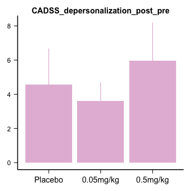

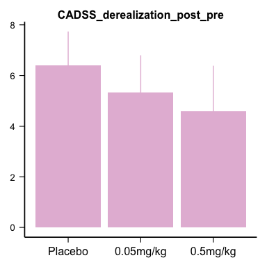

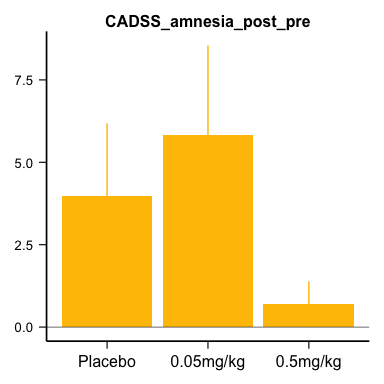

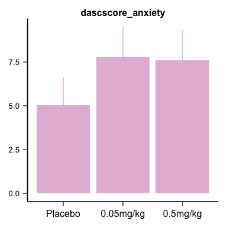

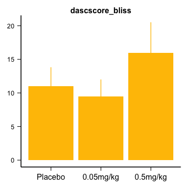

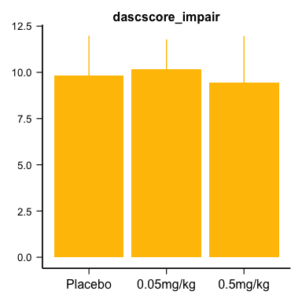

```r
# combine all CADSS and 5D-ASC subcomponents of all three visits
non_brain_data_post_pre <- Reduce(function(x, y) merge(x, y, by = c("Subjects", "Dosage"),
    all = TRUE), list(data_repeated_post_pre, data_once_pervisit))

data_fortest <- non_brain_data_post_pre %>%
    select(Subjects, Dosage, CADSS_depersonalization_post_pre, CADSS_derealization_post_pre,
        CADSS_amnesia_post_pre, dascscore_anxiety, dascscore_bliss, dascscore_impair) %>%
    pivot_longer(-c(Subjects, Dosage), names_to = "variables", values_to = "value") %>%
    mutate(Dosage = factor(Dosage, levels = dosage_level))

# by subject by variable
plot_variables <- unique(data_fortest$variables)

plot_titles <- unique(data_fortest$variables)
figure_width = 0.7
figure_height = 1.2
boxplot_width = 0.4/figure_width
colors_network = c("#E5BBD8", "#E5BBD8", "#ffc100", "#E5BBD8", "#ffc100", "#ffc100",
    "#ffc100")
xlabel_text = c("Placebo", "0.05mg/kg", "0.5mg/kg")
# xlabel_text = c('Placebo','0.5mg/kg')
for (ivar in 1:length(plot_variables)) {
    # summarize mean and sd
    data_fortest_sta <- data_fortest %>%
        filter(variables == plot_variables[ivar]) %>%
        group_by(Dosage) %>%
        summarise(count = sum(!is.na(value)), sd = sd(value, na.rm = TRUE), se = sd/sqrt(count),
            avg = mean(value, na.rm = TRUE))

    ylim_max <- max(data_fortest_sta$avg) + 1.2 * max(data_fortest_sta$se)
    ylim_min <- min(data_fortest_sta$avg) - 1.2 * max(data_fortest_sta$se)

    if (ylim_min < 0 & min(data_fortest_sta$avg) >= 0) {
        ylim_min = 0

    }

    colors_network_plot <- c(colors_network[ivar], colors_network[ivar], colors_network[ivar])
    myplot <- data_fortest_sta %>%
        ggplot(aes(x = Dosage, y = avg)) + geom_col(aes(group = Dosage, fill = Dosage),
        alpha = 1, size = 0.25) + geom_errorbar(aes(group = Dosage, color = Dosage,
        ymin = avg - se, ymax = avg + se), width = 0, size = 0.25) + scale_x_discrete(breaks = waiver(),
        labels = xlabel_text) + theme_classic() + theme(axis.ticks = element_line(size = 0.2),
        axis.line = element_line(size = 0.2), axis.text.x = element_text(size = 9),
        axis.title.y = element_blank(), strip.text.x = element_text(size = 8, colour = "black"),
        panel.margin = unit(0.25, "lines"), legend.position = "bottom", legend.margin = margin(t = -10),
        legend.spacing.y = unit(-0.05, "cm")) + scale_colour_manual(values = colors_network_plot) +
        scale_fill_manual(values = colors_network_plot) + guides(color = guide_legend(override.aes = list(alpha = 0.5))) +
        guides(col = guide_legend(nrow = 1)) + ggtitle(plot_variables[ivar])

    if (ylim_min <= 0) {
        myplot <- myplot + geom_hline(yintercept = 0, size = 0.1)
    }

    figure_width = 1.3
    xtitle_size = 6
    title_size = 6
    legend_title_size = 3
    myplot <- add_theme(myplot, xtitle_size, title_size, legend_title_size)
    myplot <- myplot + scale_colour_manual(values = colors_network_plot) + scale_fill_manual(values = colors_network_plot)
    leg <- get_legend(myplot)
    plot_leg <- as_ggplot(leg)
    myplot <- myplot + theme(legend.position = "off")
    print(myplot)
}
```

```r
task_name <- c('nonconscious')
con_name <- c('ThreatvsNeutral')

for (i_task in task_name) {
  for (i_con in con_name) {
    print(paste0("Task: ", i_task,"; Contrast: ", i_con,"\n"))

    data_fortest <- Faces_data %>%
      filter(Task == i_task, Contrast == i_con) %>%
      pivot_longer(-c(Subjects, Dosage, Task, Contrast), names_to = "variables", values_to = "value")

    # run LME and generate statistics
    rois = unique(data_fortest$variables)
    formula <-  as.formula(paste("value ~ Dosage + (1|Subjects)", sep = ""))
    print(data_fortest %>%
            filter(variables %in% rois) %>%
            split(.$variables) %>%
            map(~anova(lmer(formula,data = ., REML = FALSE)), type = 'marginal') %>%
            tibble(
              dvsub = names(.),
              untidied = .
            ) %>%
            mutate(tidy = map(untidied, broom::tidy)) %>%
            unnest(tidy) %>%
            select(-untidied) %>%
            adjust_pvalue(method = "fdr")%>%
            add_significance() %>%
            select(dvsub, term, NumDF,DenDF, statistic, p.value, p.value.adj) %>%
            rename("y" = "dvsub", "x" = "term", "Fstats" = "statistic") %>%
            kbl(caption = "ANOVA results for FEET task activations LME: y ~ Dosage + Age + Sex + (1|Subjects)") %>%
            kable_classic(full_width = F, html_font = "Arial", font_size = 10))
    # running post-hoc paired t-test for suppl. table 1
  stat.test <- data_fortest %>%
      group_by(variables) %>%
      t_test(value ~ Dosage, paired = TRUE) %>% #
      add_significance(.,"p","p.signif")

  stat.test %>%
  select(colnames(.)[c(-2, -5:-6, -10:-11, -13:-16)]) %>%
  mutate(group = paste0(group1,' vs ',  group2, sep= "")) %>%
  select(-group1, -group2) %>%
  pivot_wider(names_from = group, values_from = c(statistic, df, p, p.signif)) %>%
  kbl(caption = "suppl. table1: post-hoc t test") %>%
  kable_classic(full_width = F, html_font = "Arial", font_size = 10)

   # generate column plots
    plot_variables <- rois
    plot_titles <- c("antInsula R", "Amygdala R")
    figure_width = 0.7
    figure_height = 1.2
    boxplot_width = 0.4/figure_width
    xlabel_text = c("Placebo","0.05mg/kg","0.5mg/kg")
    colors_network =  c("#46B674", "#D77842")


    for (ivar in 1:length(plot_variables)) {

      # generate significance
      stat.test <- data_fortest %>%
        filter(variables == plot_variables[ivar]) %>%
        group_by(variables) %>%
        t_test(value ~ Dosage, paired = TRUE) %>%
        add_significance(.,"p","p.signif")%>%
        add_xy_position(x = "Dosage", scales = "free")%>%
        filter(p < 0.05)

      subjN = length(unique(data_fortest$Subjects))

      # summarize mean and sd
      data_fortest_sta <- data_fortest %>%
        filter(variables == plot_variables[ivar]) %>%
        group_by(Dosage) %>%
        summarise(
          count = sum(!is.na(value)),
          sd = sd(value, na.rm = TRUE),
          se = sd / sqrt(count),
          avg = mean(value, na.rm = TRUE))




      ylim_max <- max(data_fortest_sta$avg) + 1.1 * max(data_fortest_sta$se)
  ylim_min <- min(data_fortest_sta$avg) - 1.1 * max(data_fortest_sta$se)

  colors_network_plot <- c(colors_network[ivar], colors_network[ivar], colors_network[ivar])

     myplot <- data_fortest_sta %>%
        ggplot(aes(x = Dosage, y = avg)) +
        geom_col(aes(group = Dosage, fill = Dosage), alpha = 1, size = 0.25) +
        geom_errorbar(aes(group = Dosage, color = Dosage, ymin = avg-se, ymax = avg+se), width = 0, size = 0.25) + guides(color = guide_legend(override.aes= list(alpha = 0.5))) + scale_x_discrete(breaks = waiver(), labels = xlabel_text) + scale_y_continuous(name="Size of effect", limits=c(-0.3, 0.75), breaks = c(-0.25, 0, 0.25, 0.5, 0.75), expand = c(0, 0)) + theme_classic() + theme(axis.ticks = element_line(size = 0.2), axis.line = element_line(size = 0.2),
    axis.text.x = element_text(size = 9),
        axis.title.y=element_blank(),
        strip.text.x = element_text(size = 8, colour = "black"),
        panel.margin = unit(0.25, "lines"), legend.position="bottom", legend.margin=margin(t=-10),
        legend.spacing.y = unit(-0.05, 'cm')) + scale_colour_manual(values = colors_network_plot) + scale_fill_manual(values = colors_network_plot) + guides(color = guide_legend(override.aes= list(alpha = 0.5))) + guides(col = guide_legend(nrow = 1))  + ggtitle(plot_variables[ivar])
      if (ylim_min < 0) {
      myplot <- myplot + geom_hline(yintercept = 0, size = 0.1)
      }

      xtitle_size = 6
      title_size = 6
      legend_title_size = 3
      myplot <- add_theme(myplot, xtitle_size, title_size, legend_title_size)
      myplot <- myplot+scale_colour_manual(values = colors_network_plot) + scale_fill_manual(values = colors_network_plot)
      leg <- get_legend(myplot)
      plot_leg <- as_ggplot(leg)
      myplot <- myplot + theme(legend.position = "off")
      print(myplot)
    }


  }

}
```

[1] “Task: nonconscious; Contrast: ThreatvsNeutral”

| y | x | NumDF | DenDF | Fstats | p.value | p.value.adj |
| --- | --- | --- | --- | --- | --- | --- |
| Right_Amygdala_peak_nonconscious | Dosage | 2 | 25.43714 | 0.5742316 | 0.5702696 | 0.8908732 |
| Right_antInsula_peak_nonconscious | Dosage | 2 | 37.00000 | 0.1159149 | 0.8908732 | 0.8908732 |

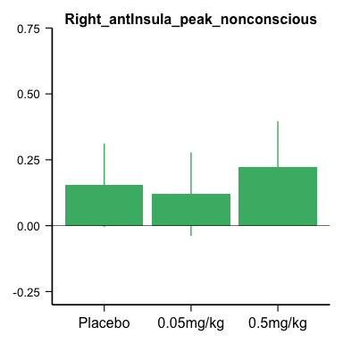

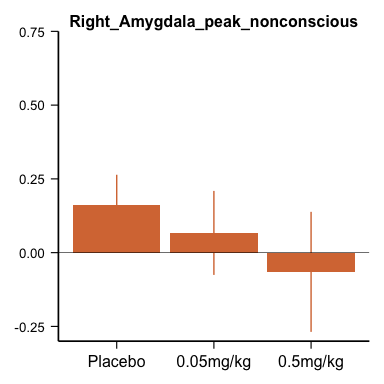